# TPC 5-Estatística computacional

João Francisco Botas, nº104782

30/09/2022

# Variáveis aleatórias

## Exercício 1

> Sabe-se que nos municípios de uma certa região turística, $40%$ mais que duplicam a sua população nos meses de verão. Suponha que o acréscimo no consumo de água por cada turista alojado, por dia, pode ser descrito através de uma variável aleatória com distribuição Normal, de média $0,50 m^3$ e desvio-padrão $0,05 m^3$.

Com isto sabe-se que $\mu=0.50 m^3$ e $\sigma=0.05 m^3$.

```
## Foram guardadas as variáveis da média (como miuX1) e do desvio padrão (como sigmaX1) que correspondem a 0.5 e 0.05 , respetivamente.
```

Com as variáveis criadas para as duas medidas, passamos para as alíneas.

### a)

> Qual a probabilidade do acréscimo no consumo, por turista e por dia, ser inferior a $0,437 m^3$?

Seja $X_1$- acréscimo no consumo de água por cada turista alojado em que;

$X_1\sim N(0.5,0.05)$

Com as variáveis criadas fazemos a probabilidade pretendida.

```r
norm1a <- pnorm(0.437,mean=miuX1,sd=sigmaX1,lower.tail = TRUE)
norm1a
```

```
## [1] 0.1038347
```

Assim, concluímos que a probabilidade do acréscimo ser inferior a *0.437*, $P[X_1<0.437]$, é igual a **0.1038347**.

### b)

> Calcule o maior acréscimo de consumo dos 25% menores acréscimos.

Para calcular o maior acréscimo de consumo dos 25% menores acréscimos é necessário utilizar a função *qnorm* e encontrar o valor correspondente ao 1º quartil, ou seja, onde na amostra o valor máximo dos 25% primeiros:

$P[X_1\le corte]=0.25$, em que o corte representa a probabilidade pretendida

O modelo probabilístico será igual ao da *alínea a)*: $X_1\sim N(0.5,0.05)$

```r
norm1b <- qnorm(0.25,mean=miuX1,sd=sigmaX1,lower.tail = TRUE)
norm1b
```

```
## [1] 0.4662755
```

Como output foi dado o valor do corte do 1º quartil (*25%*), corte= **0.4662755**.

### c)

> Numa certa unidade de turismo rural casa, a capacidade é de 20 hóspedes. Considerando um momento em que a unidade está totalmente cheia, qual a probabilidade do consumo de água diário aumentar em pelo menos $10,75 m^3$?

Seja $X_2$- acréscimo no consumo de água diário por cada 20 turistas alojados.

Será utilizado o teorema da aditividade da normal, pois os hóspedes são variáveis aleatórias independentes e identicamente distribuídas. Logo, pelo corolário da aditividade da normal chega-se à fórmula/modelo probabilístico seguinte:

$$T=\sum_{i=1}^{20}X_i\sim
N(\mu_T=20\mu,\sigma_T=\sigma\sqrt{20})$$
, onde $\mu$ e $\sigma$ representam os valores da média e desvio padrão do consumo diário, por turista, respetivamente. $X_2\sim N(0.5\times 20,0.05\times \sqrt{20})$

Ou seja, a probabilidade será dada na forma: $P[X_2\ge 10.75]$

```r
miuT <- miuX1*20
sigmaT <- sigmaX1*sqrt(20)
norm1c <- pnorm(10.75,mean=miuT,sd=sigmaT,lower.tail=FALSE)
norm1c
```

```
## [1] 0.0003981151
```

Com isto, o valor retirado para a probabilidade será de **3.9811508^{-4}**.

### d)

> Em relação à casa de turismo rural da alínea anterior:
> 1. Simule uma observação do acréscimo de consumo de água de 20 hóspedes dessa casa de turismo rural. Pretende-se que simule o acréscimo de consumo gerado por cada um desses 20 hóspedes, e que reporte os acréscimos individuais e o acréscimo total (soma dos acréscimos) para esta simulação.
1. De forma a fazer a simulação de uma observação, será utilizado o comando *rnorm* com o n=20, que irão corresponder aos 20 hóspedes, e com os valores de $\mu$ e $\sigma$ calculados face ao problema da alínea *c)*. Por fim, iremos calcular a soma dos valores que estão no vetor que corresponderá ao acréscimo total.

```r
rnorm1di <- rnorm(20,mean=miuT,sd=sigmaT)
rnorm1di
```

```
##  [1]  9.941773  9.680050 10.023930  9.553319 10.022210 10.304252  9.963911
##  [8] 10.138220 10.125526 10.096791 10.000431 10.219801  9.925862  9.893282
## [15] 10.207548 10.158714 10.146184 10.302807 10.339419  9.923141
```

```r
soma <- sum(rnorm1di)
soma
```

```
## [1] 200.9672
```

> 2. Simule 1000 observações nas mesmas condições, guardando apenas a soma para cada uma delas, e, com base nessa simulação, estime a probabilidade que calculou de forma exata em c)
2. Agora pretendem-se fazer 1000 observações mas somente com os valores das somas geradas na alínea anterior(*alínea d)i)*), com a função *rnorm*. Para realizar isto utiliza-se a função *replicate* para replicar 1000 vezes o vetor com a soma dos acréscimos dos 20 hóspedes.

```r
rnorm1dii <- replicate(1000,sum(rnorm(20,mean=miuX1,sd=sigmaX1)))
length(which(rnorm1dii>=10.75))/length(rnorm1dii)
```

```
## [1] 0
```

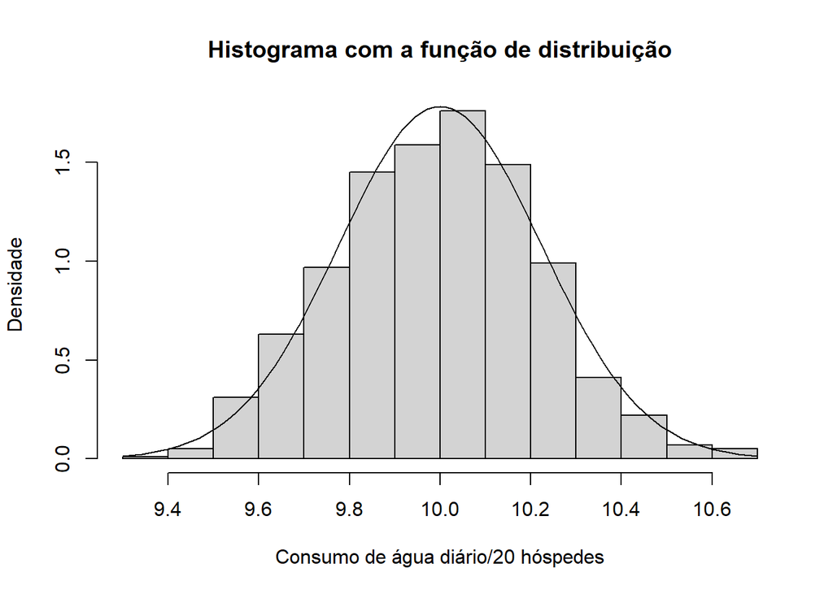

```r
# histograma com densidade
hist(rnorm1dii,freq=FALSE,xlab="Consumo de água diário/20 hóspedes",ylab="Densidade",main="Histograma com a função de distribuição")
curve(dnorm(x,10,0.2236),add=TRUE)
```

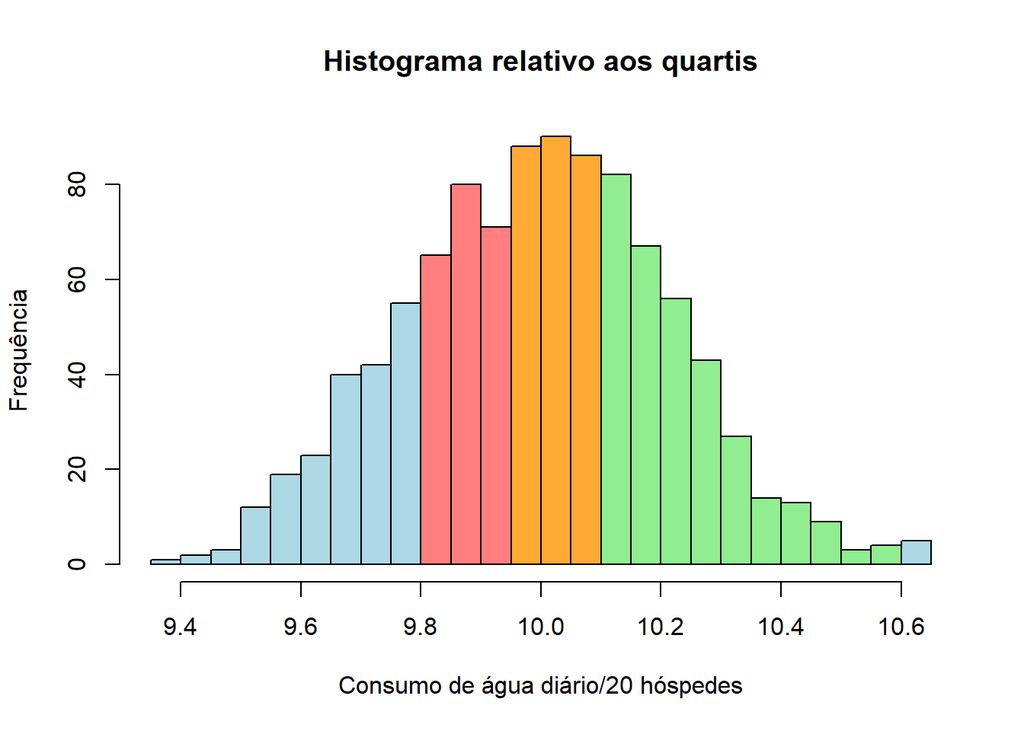

```r
# histograma com quartis
h <- hist(rnorm1dii,breaks=20,plot=FALSE)
cols <- c( "light blue", "#FF7F7F", "#FFAA33", "light green")
k <- cols[findInterval(h$mids, quantile(rnorm1dii), rightmost.closed=T, all.inside=F)]
plot(h, col=k,xlab="Consumo de água diário/20 hóspedes",ylab="Frequência",main="Histograma relativo aos quartis")
```